# Tarea 1: Regresión para Estimar Ingreso

Ariela Díaz

2025-04-21

# 1. Introducción

La Encuesta de Caracterización Socioeconómica Nacional (CASEN) es una herramienta fundamental para el análisis de las condiciones de vida de la población en Chile, gracias a su amplia cobertura temática y territorial, lo que permite estudiar variables claves como educación, salud, vivienda, empleo e ingresos.

Según la División Observatorio Social, en la Encuesta CASEN el concepto de ingreso corresponde al ingreso corriente disponible del hogar, también denominado ingreso total. Este se compone de la suma del ingreso primario o autónomo y las transferencias corrientes percibidas por el hogar, e incluye además el valor de los servicios imputados al uso de la vivienda.

En este estudio, se utiliza el **ingreso per cápita**, que corresponde al ingreso total del hogar dividido por el número de integrantes del mismo. Esta medida permite comparar de manera más justa el bienestar económico entre personas de hogares de distinto tamaño, ofreciendo una aproximación más precisa a las desigualdades socioeconómicas individuales.

En este contexto, el presente trabajo tiene como propósito aplicar técnicas de análisis de datos y modelos de regresión lineal para identificar y cuantificar los principales determinantes del ingreso per cápita de las personas residentes en la Región Metropolitana, a partir de la base de datos CASEN 2022.

## 1.1. Objetivos

### 1.1.1. Objetivo Principal

En función a lo anterior, el presente informe tiene como objetivo principal analizar los factores sociodemográficos que inciden en el ingreso per cápita de las personas residentes en la Región Metropolitana utilizando técnicas de regresión lineal a partir de la Encuesta CASEN 2022.

### 1.1.2. Objetivos Secundarios

Los objetivos específicos por trabajar son:

- Seleccionar y preprarar una base de datos que contengan las variables relevantes para el estudio del ingreso.
- Realizar un proceso de limpieza de datos, eliminando observaciones con valores atípicos. y vacíos.
- Efectuar un análisis exploratorio para comprender la distribución y comportamiento de las variables seleccionadas.
- Evaluar correlación entre el ingreso per cápita y las variables.
- Estimar un modelo de regresión lineal que permita cuantificar el efecto de dichas variables sobre el ingreso.
- Interpretar los resultados obtenidos del modelo, destacando variables significativas.

# 2. Metodología

El desarrollo de este estudio se llevó a cabo a partir de la base de datos de la Encuesta CASEN 2022, restringida en la Región Metropolitana (RM). Para hacer un análisis se siguieron una serie de pasos, los cuales permiten preparar, explorar y modelar los datos:

## 2.1. Librerías necesarias

Para realizar el análisis estadístico y gráficos, se utilizaron diversas librerías del lenguaje R.

Estas permiten cargar la base de datos, transformarla, visualizarla y construir modelos. Las principales librerías utilizadas son:

```r
library(tidyverse)
library(haven)
library(ggplot2)
library(corrplot)
library(ggcorrplot)
library(scales)
```

Cada paquete tiene una función diferente.

| Librería | Función |
| --- | --- |
| `tidyverse` | Manipulación y visualización de datos. |
| `haven` | Lectura de archivos `.rds` de CASEN. |
| `ggplot` `corrplot` `ggcorrplot` | Visualización de datos y correlaciones. |
| `scales` | Mejora el formato de ejes numéricos. |

## 2.2. Carga de Datos

Se utilizó una versión filtrada previamente de la base CASEN 2022 correspondiente a la región de estudio (RM). Esta fue cargada en formato `.rds`, que es un formato propio de R para conservar la estructura de los datos.

```r
ruta_rds = "../data/casen_rm.rds"
casen_rm = readRDS(ruta_rds)
```

## 2.3. Selección y transformación de variables

En esta etapa se seleccionaron las siguientes variables:

| Variable | Información |
| --- | --- |
| `ypc` | Ingreso per cápita |
| `e6a` | Nivel educacional más alto que asiste o asistió. |
| `edad` | Edad de la persona entrevistada |
| `sexo` | Sexo de la persona entrevistada |
| `o25` | Tamaño de la empresa |

Además, se hizo la transformacion de la variable categóricas `sexo` en factor, lo que es necesario para el análisis estadístico y modelos. Y se establecen restricciones como:

- El ingreso debe ser mayor a 0.  
  $ingreso > 0$
- La edad de la persona entrevistada debe ser mayor a 15 años y menor a 65 años.  
  $edad ≥ 15$ & $edad ≤ 65$
- Se trabaja con el 80% de los datos.

# 3. Resultados

## 3.1. Análisis exploratorio

Una vez que los datos fueron limpiados, se procedió a una exploración inicial de las variables seleccionadas, con el fin de conocer y entender su comportamiento y distribución. A continuación, se presenta un resumen estadístico y visualizaciones relevantes.

### 3.1.1. Estadística Descriptiva

Se trabaja con la función `summary()`, ya que se utiliza para analizar variables numéricas, proporcionando medidas como la mediana, el valor mínimo y máximo, la media, entre otras. Este método permite obtener una visión general de la distribución y características de los datos considerados.

```
##     ingreso            educ            edad        tam_empresa      sexo
##  Min.   :  7500   Min.   : 1.00   Min.   :15.00   Min.   :-88.000   1:7300
##  1st Qu.:286111   1st Qu.: 9.00   1st Qu.:30.00   1st Qu.:  1.000   2:6446
##  Median :420334   Median :11.00   Median :40.00   Median :  4.000
##  Mean   :456274   Mean   :10.43   Mean   :41.03   Mean   : -1.557
##  3rd Qu.:600000   3rd Qu.:12.00   3rd Qu.:52.00   3rd Qu.:  5.000
##  Max.   :994834   Max.   :15.00   Max.   :65.00   Max.   :  6.000
```

El análisis estadístico de las variables revela tendencias clave en los datos. El **ingreso per cápita** muestra una distribución asimétrica con una media de **$456.274** y una mediana inferior, lo que indica la influencia de valores altos en el promedio. En cuanto al **nivel educativo**, la mayoría de la muestra ha completado la educación básica, con una media de 10,43 años y una mediana de 11, mientras que el máximo registrado corresponde a estudios superiores (15 años). La **edad** de la muestra oscila entre 15 y 65 años, con una distribución simétrica en torno a la media de 41 años y una mediana de 40, lo que sugiere que la mayoría está en plena edad laboral.

Respecto al **tamaño de empresa**, la media negativa (-1,557) indica posibles inconsistencias en los datos, aunque la mayoría de los trabajadores pertenece a empresas pequeñas o medianas, con percentiles entre 1 y 5. Finalmente, el análisis del **sexo** revela una distribución equilibrada, con una ligera mayoría masculina (7.300 hombres frente a 6.446 mujeres).

Este resumen permite visualizar patrones en las variables clave, facilitando una interpretación clara de las características de la muestra.

### 3.1.2. Análisis Exploratorio con Gráficos

Para hacernos una idea de como se distribuyen las variables, generamos histogramas y boxplots.

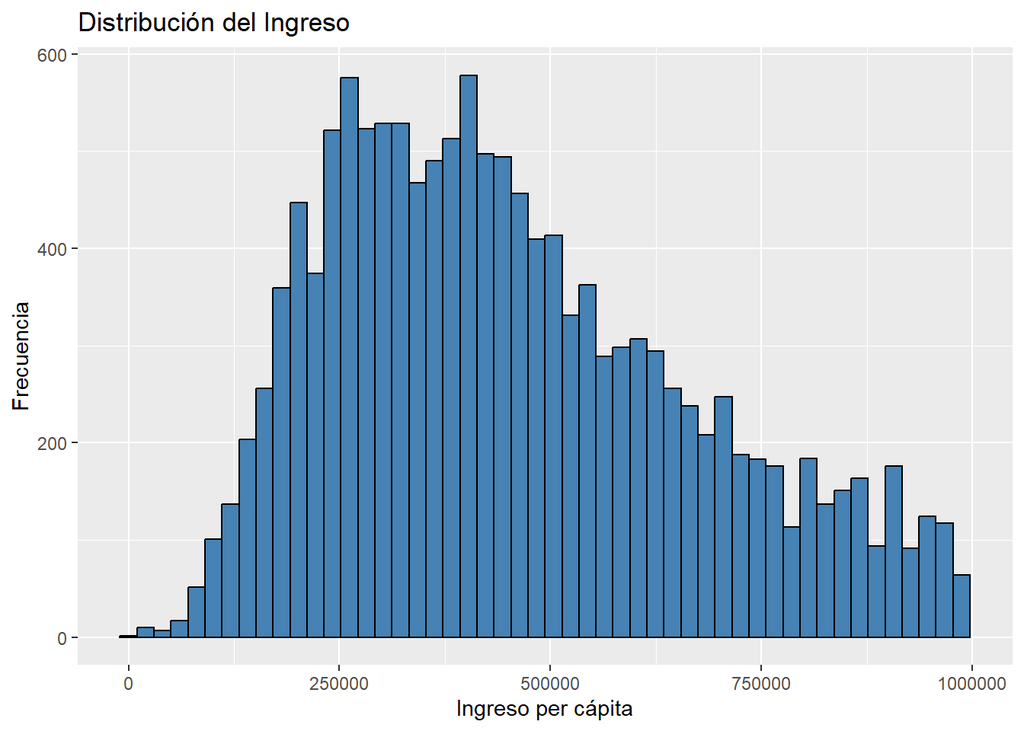

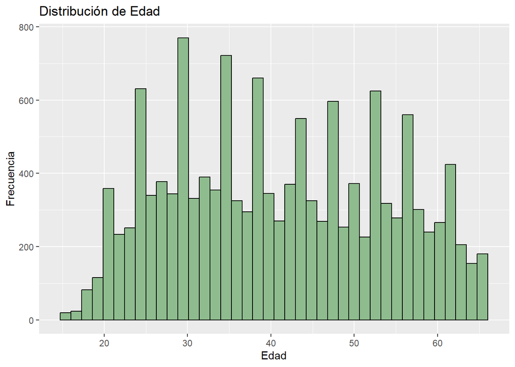

A continuación, se realizan boxplots para ver la relación entre el ingreso y variables como el sexo y la educación.

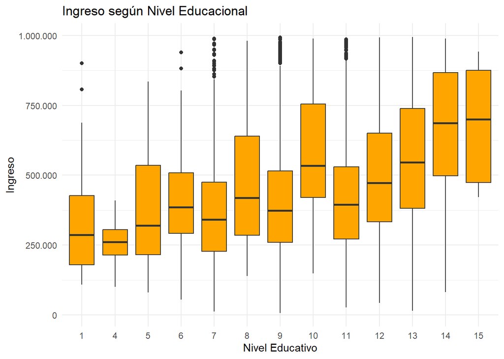

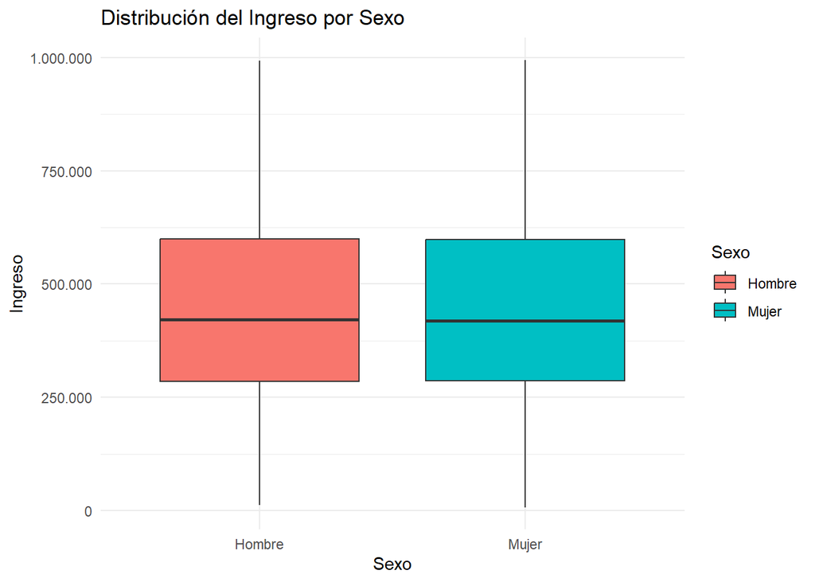

## 3.2. Matriz de Correlación

Luego del análisis visual, se calcula la matriz de correlación entre las variables numéricas seleccionadas para el estudio. Con la finalidad de identificar la intensidad y dirección de la relación lineal entre el ingreso y las variables predictoras, esto nos permite tener una visión preliminar de qué factores podrían tener mayor relevancia al momento de construir el modelo de regresión posteriormente.

Para el análisis fue necesaria la transformación de la variable sexo, originalmente categórica, a formato numérico para su inclusión en el cálculo. A continuación se muestra la transformación.

```r
# Convertimos variables categóricas a numéricas para correlación
casen_cor = casen %>%
  mutate(
    sexo = as.numeric(sexo)
  )
```

La correlación toma valores entre -1 y 1, donde valores cercanos indican una fuerte relación positiva, valores cercanos a -1 indican una fuerte relación negativa, y valores cercanos a 0 indican ausencia de relacion lineal.

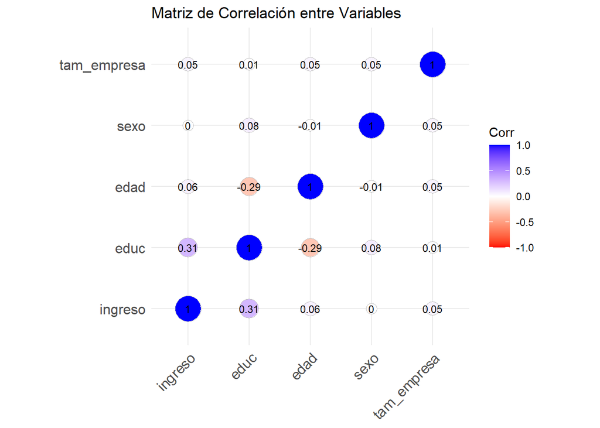

```
##                variable  correlacion     abs_cor
## educ               educ  0.311803379 0.311803379
## edad               edad  0.057891522 0.057891522
## tam_empresa tam_empresa  0.052852621 0.052852621
## sexo               sexo -0.000603815 0.000603815
```

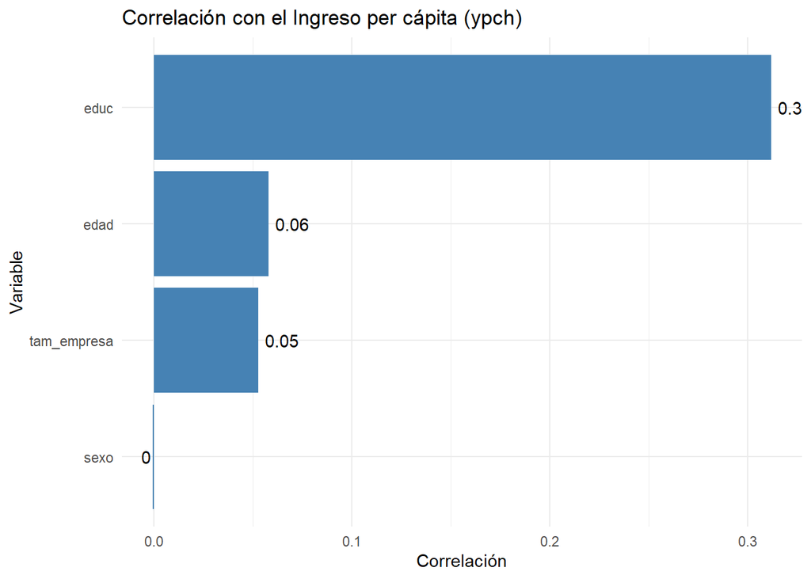

A través de esta matriz es posible observar:

- Las correlaciones más destacadas son:
  - **Ingreso y educación** tienen una correlación positiva de **0.31**, lo que sugiere que un mayor nivel educativo tiende a estar asociado con mayores ingresos.
  - **Edad y educación** presentan una correlación negativa de **-0.29**, indicando que en esta muestra, las personas mayores suelen tener menos años de educación formal.
- Las demás correlaciones son cercanas a cero, lo que sugiere que no hay relaciones fuertes entre las otras variables analizadas.

## 3.3. Modelo de Regresión Lineal

El modelo lineal multiple planteado tiene la siguiente forma:

$Ingreso = 𝛽_0 + 𝛽_1 * Tamaño Empresa + 𝛽_2 * Educación + 𝛽_3 * Edad + 𝛽_4 * Sexo_i+ 𝜀_i$

Donde:

- $𝛽_0$ : es el intercepto del modelo.
- $𝛽_1,𝛽_2,𝛽_3,𝛽_4$ : son los coeficientes estimados para cada variable.
- $𝜀_i$ : error.

Se utiliza nuevamente `summary()`para visualizar los resultados.

```r
summary(modelo)
```

```
##
## Call:
## lm(formula = ingreso ~ tam_empresa + educ + edad + sexo, data = casen)
##
## Residuals:
##     Min      1Q  Median      3Q     Max
## -564114 -152583  -28324  131061  744114
##
## Coefficients:
##              Estimate Std. Error t value Pr(>|t|)
## (Intercept) -27100.63   12006.23  -2.257    0.024 *
## tam_empresa    434.19      81.19   5.348 9.03e-08 ***
## educ         36378.62     845.31  43.036  < 2e-16 ***
## edad          2711.19     141.44  19.168  < 2e-16 ***
## sexo2       -13786.09    3456.36  -3.989 6.68e-05 ***
## ---
## Signif. codes:  0 '***' 0.001 '**' 0.01 '*' 0.05 '.' 0.1 ' ' 1
##
## Residual standard error: 201200 on 13741 degrees of freedom
## Multiple R-squared:  0.124,  Adjusted R-squared:  0.1237
## F-statistic: 486.1 on 4 and 13741 DF,  p-value: < 2.2e-16
```

A partir de lo entregado anteriormente, se puede mencionar que el resumen del modelo entrega información clave sobre los coeficientes estimados, su significancia estadística y el grado de ajuste global:

- Intercepto ($𝛽_0$): Tiene un valor de **-27,100**, este es un valor estimado del ingreso cuando todas las variables explicativas seleccionadas son 0 (esto no tiene una interpretacion práctica directa, pero es necesario para ajustar la recta de regresión).
- Tamaño Empresa ($𝛽_1$): Por cada unidad adicional en el tamaño de la empresa (más grande), el ingreso mensual estimado aumenta en **$434**, manteniendo las demás variables constantes. Esto sugiere una relación positiva entre el tamaño del empleador y los ingresos percibidos.
- Educación ($𝛽_2$): Por cada nivel adicional de educación alcanzado, el ingreso aumente en promedio **$36.378**, lo cual muestra un efecto fuerte y altamente siginifcativo de la educación en el nivel de ingresos.
- Edad ($𝛽_3$): Cada año adicional de edad se asocia con un incremento promedio de **$2.711** en el ingreso, lo que podría reflejar la experiencia laboral acumulada.
- Sexo<sub>2</sub> ($𝛽_4$): Al ser mujer (sexo codificado como 2), se asocia con una disminución promedio de **$13.786** en el ingreso respecto a los hombres, manteniendo constantes las demás variables. Este coefeciente refleja una brecha de género en ingresos significativa y negativa hacia las mujeres.

El coeficiente de determinación **R² = 0.124** indica que el modelo explica aproximadamente el 12.4% de la variabilidad en el ingreso. Aunque este valor es relativamente bajo, es común en estudios sociales donde intervienen múltiples factores no observados, sugiriendo que existen otras variables que influyen en los ingresos además de las consideradas en el modelo.

Por otro lado, la **F-statistic = 486.1**, con un **p-valor < 2.2e-16**, confirma que el modelo es estadísticamente significativo, lo que implica que al menos una de las variables explicativas tiene un impacto real en el ingreso.

### 3.3.1. Diagnóstico

Ya ajustado el modelo, es importante hacer un análisis de diagnóstico para evaluar si se cumplen los supuestos de la regresión lineal como:

- Linealidad; La relación entre las variables independientes y la dependiente debe ser lineal.
- Independencia de los errores: Los residuos (errores del modelo) deben ser independientes entre sí.
- Homocedasticidad: Los residuos deben tener varianza constante (no mostrar patrones)
- Normalidad de los residuos: Los errores deben distribuirse normalmente.

Para revisar el cumplimiento de estos supuestos, se utilizan gráficos de diagnóstico generados por la función `plot()`.

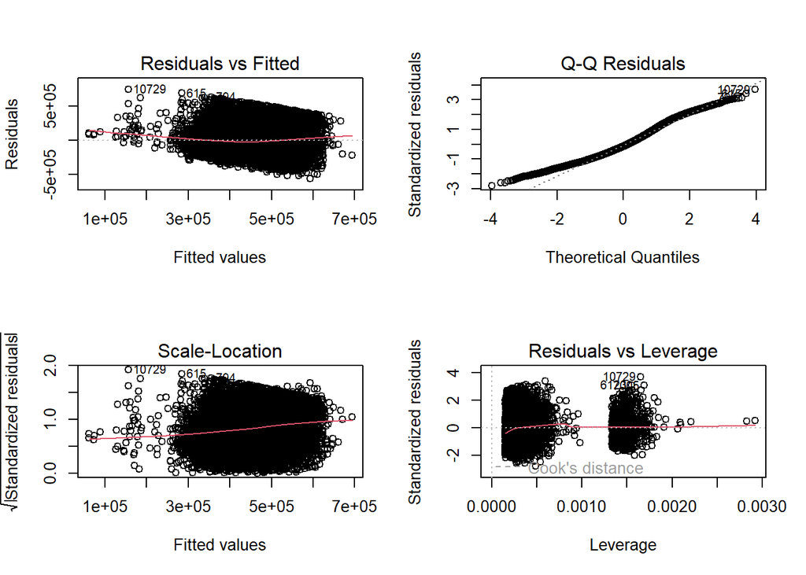

## 3.4. Modelo logarítmico

El modelo estima `log(ingreso)` en función de `tam_empresa`, `educ`, `edad` y `sexo`.

$log(ingreso) = 𝛽_0 + 𝛽_1 * Tamaño Empresa + 𝛽_2 * Educación + 𝛽_3 * Edad + 𝛽_4 * Sexo_i+ 𝜀_i$

Aplicamos nuevamente `summary()`, obteniendo

```r
summary(modelo_log)
```

```
##
## Call:
## lm(formula = log_ingreso ~ tam_empresa + educ + edad + sexo,
##     data = casen)
##
## Residuals:
##     Min      1Q  Median      3Q     Max
## -3.8271 -0.3127  0.0443  0.3626  1.5000
##
## Coefficients:
##               Estimate Std. Error t value Pr(>|t|)
## (Intercept) 11.7701188  0.0292563 402.311  < 2e-16 ***
## tam_empresa  0.0009829  0.0001978   4.968 6.84e-07 ***
## educ         0.0850217  0.0020598  41.276  < 2e-16 ***
## edad         0.0065195  0.0003447  18.916  < 2e-16 ***
## sexo2       -0.0306657  0.0084223  -3.641 0.000273 ***
## ---
## Signif. codes:  0 '***' 0.001 '**' 0.01 '*' 0.05 '.' 0.1 ' ' 1
##
## Residual standard error: 0.4904 on 13741 degrees of freedom
## Multiple R-squared:  0.1155, Adjusted R-squared:  0.1153
## F-statistic: 448.6 on 4 and 13741 DF,  p-value: < 2.2e-16
```

### 3.4.1. Diagnóstico

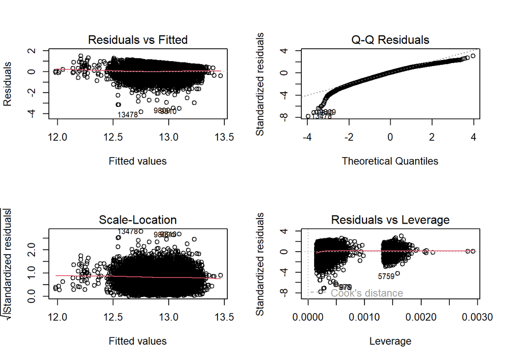

# 4. Conclusión

Para futuras investigaciones, se recomienda explorar modelos más complejos o no lineales, así como incorporar nuevas variables que permitan captar de forma más precisa los determinantes del ingreso. Esto contribuirá a una comprensión más profunda de las desigualdades económicas en la región y a fortalecer la capacidad explicativa de futuros estudios.

# Referencias

- División Observatorio Social. (2023). Nota técnica N°2 – julio 2023. Encuesta de Caracterización Socioeconómica Nacional 2022. Ministerio de Desarrollo Social y Familia.